# IP Week 13

# Exploratory Data Analysis

## Univariate Analysis

### Counts

```r
# Checking the counts of Revenue
library(plyr)
count(ons$Revenue)
```

```
##       x  freq
## 1 FALSE 10291
## 2  TRUE  1908
```

```r
# Checking the counts of those who visited on Weekend
count(ons$Weekend)
```

```
##       x freq
## 1 FALSE 9343
## 2  TRUE 2856
```

```r
# Checking the counts of visitors type
count(ons$VisitorType)
```

```
##                   x  freq
## 1       New_Visitor  1693
## 2             Other    81
## 3 Returning_Visitor 10425
```

```r
# Checking the counts of months
count(ons$Month)
```

```
##       x freq
## 1   Aug  433
## 2   Dec 1706
## 3   Feb  182
## 4   Jul  432
## 5  June  285
## 6   Mar 1853
## 7   May 3328
## 8   Nov 2983
## 9   Oct  549
## 10  Sep  448
```

### Mean

```r
mean(ons$Administrative_Duration)
```

```
## [1] 81.68214
```

```r
mean(ons$Informational_Duration)
```

```
## [1] 34.83734
```

```r
mean(ons$ProductRelated_Duration)
```

```
## [1] 1207.508
```

```r
mean(ons$BounceRates)
```

```
## [1] 0.02044674
```

```r
mean(ons$ExitRates)
```

```
## [1] 0.04149678
```

```r
mean(ons$PageValues)
```

```
## [1] 5.9525
```

```r
mean(ons$OperatingSystems)
```

```
## [1] 2.124354
```

```r
mean(ons$Browser)
```

```
## [1] 2.358144
```

### Median

```r
median(ons$Administrative_Duration)
```

```
## [1] 9
```

```r
median(ons$Informational_Duration)
```

```
## [1] 0
```

```r
median(ons$ProductRelated_Duration)
```

```
## [1] 609.5417
```

```r
median(ons$BounceRates)
```

```
## [1] 0.002930403
```

```r
median(ons$ExitRates)
```

```
## [1] 0.025
```

```r
median(ons$PageValues)
```

```
## [1] 0
```

```r
median(ons$OperatingSystems)
```

```
## [1] 2
```

```r
median(ons$Browser)
```

```
## [1] 2
```

### Mode

```r
getmode <- function(v) {
   uniqv <- unique(v)
   uniqv[which.max(tabulate(match(v, uniqv)))]
}
```

```r
mode(ons$Administrative_Duration)
```

```
## [1] "numeric"
```

```r
mode(ons$Informational_Duration)
```

```
## [1] "numeric"
```

```r
mode(ons$ProductRelated_Duration)
```

```
## [1] "numeric"
```

```r
mode(ons$BounceRates)
```

```
## [1] "numeric"
```

```r
mode(ons$ExitRates)
```

```
## [1] "numeric"
```

```r
mode(ons$PageValues)
```

```
## [1] "numeric"
```

```r
mode(ons$OperatingSystems)
```

```
## [1] "numeric"
```

```r
mode(ons$Browser)
```

```
## [1] "numeric"
```

### Maximum

```r
max(ons$Administrative_Duration)
```

```
## [1] 3398.75
```

```r
max(ons$Informational_Duration)
```

```
## [1] 2549.375
```

```r
max(ons$ProductRelated_Duration)
```

```
## [1] 63973.52
```

```r
max(ons$BounceRates)
```

```
## [1] 0.2
```

```r
max(ons$ExitRates)
```

```
## [1] 0.2
```

```r
max(ons$PageValues)
```

```
## [1] 361.7637
```

```r
max(ons$OperatingSystems)
```

```
## [1] 8
```

```r
max(ons$Browser)
```

```
## [1] 13
```

### Minimum

```r
min(ons$Administrative_Duration)
```

```
## [1] -1
```

```r
min(ons$Informational_Duration)
```

```
## [1] -1
```

```r
min(ons$ProductRelated_Duration)
```

```
## [1] -1
```

```r
min(ons$BounceRates)
```

```
## [1] 0
```

```r
min(ons$ExitRates)
```

```
## [1] 0
```

```r
min(ons$PageValues)
```

```
## [1] 0
```

```r
min(ons$OperatingSystems)
```

```
## [1] 1
```

```r
min(ons$Browser)
```

```
## [1] 1
```

### Range

```r
range(ons$Administrative_Duration)
```

```
## [1]   -1.00 3398.75
```

```r
range(ons$Informational_Duration)
```

```
## [1]   -1.000 2549.375
```

```r
range(ons$ProductRelated_Duration)
```

```
## [1]    -1.00 63973.52
```

```r
range(ons$BounceRates)
```

```
## [1] 0.0 0.2
```

```r
range(ons$ExitRates)
```

```
## [1] 0.0 0.2
```

```r
range(ons$PageValues)
```

```
## [1]   0.0000 361.7637
```

```r
range(ons$OperatingSystems)
```

```
## [1] 1 8
```

```r
range(ons$Browser)
```

```
## [1]  1 13
```

### Quantile

```r
quantile(ons$Administrative_Duration)
```

```
##      0%     25%     50%     75%    100%
##   -1.00    0.00    9.00   94.75 3398.75
```

```r
quantile(ons$Informational_Duration)
```

```
##       0%      25%      50%      75%     100%
##   -1.000    0.000    0.000    0.000 2549.375
```

```r
quantile(ons$ProductRelated_Duration)
```

```
##         0%        25%        50%        75%       100%
##    -1.0000   193.5833   609.5417  1477.5648 63973.5222
```

```r
quantile(ons$BounceRates)
```

```
##          0%         25%         50%         75%        100%
## 0.000000000 0.000000000 0.002930403 0.016666667 0.200000000
```

```r
quantile(ons$ExitRates)
```

```
##         0%        25%        50%        75%       100%
## 0.00000000 0.01422258 0.02500000 0.04848485 0.20000000
```

```r
quantile(ons$PageValues)
```

```
##       0%      25%      50%      75%     100%
##   0.0000   0.0000   0.0000   0.0000 361.7637
```

```r
quantile(ons$OperatingSystems)
```

```
##   0%  25%  50%  75% 100%
##    1    2    2    3    8
```

```r
quantile(ons$Browser)
```

```
##   0%  25%  50%  75% 100%
##    1    2    2    2   13
```

### Interquantile Range

```r
IQR(ons$Administrative_Duration)
```

```
## [1] 94.75
```

```r
IQR(ons$Informational_Duration)
```

```
## [1] 0
```

```r
IQR(ons$ProductRelated_Duration)
```

```
## [1] 1283.981
```

```r
IQR(ons$BounceRates)
```

```
## [1] 0.01666667
```

```r
IQR(ons$ExitRates)
```

```
## [1] 0.03426227
```

```r
IQR(ons$PageValues)
```

```
## [1] 0
```

```r
IQR(ons$OperatingSystems)
```

```
## [1] 1
```

```r
IQR(ons$Browser)
```

```
## [1] 0
```

### Variance

```r
var(ons$Administrative_Duration)
```

```
## [1] 31516.25
```

```r
var(ons$Informational_Duration)
```

```
## [1] 20010.51
```

```r
var(ons$ProductRelated_Duration)
```

```
## [1] 3686121
```

```r
var(ons$BounceRates)
```

```
## [1] 0.002061387
```

```r
var(ons$ExitRates)
```

```
## [1] 0.0021388
```

```r
var(ons$PageValues)
```

```
## [1] 348.1132
```

```r
var(ons$OperatingSystems)
```

```
## [1] 0.8226229
```

```r
var(ons$Browser)
```

```
## [1] 2.926075
```

### Standard Deviation

```r
sd(ons$Administrative_Duration)
```

```
## [1] 177.5282
```

```r
sd(ons$Informational_Duration)
```

```
## [1] 141.4585
```

```r
sd(ons$ProductRelated_Duration)
```

```
## [1] 1919.927
```

```r
sd(ons$BounceRates)
```

```
## [1] 0.0454025
```

```r
sd(ons$ExitRates)
```

```
## [1] 0.04624716
```

```r
sd(ons$PageValues)
```

```
## [1] 18.65779
```

```r
sd(ons$OperatingSystems)
```

```
## [1] 0.9069856
```

```r
sd(ons$Browser)
```

```
## [1] 1.710578
```

### Skewness

```r
library(e1071)
skewness(ons$Administrative_Duration)
```

```
## [1] 5.589523
```

```r
skewness(ons$Informational_Duration)
```

```
## [1] 7.536508
```

```r
skewness(ons$ProductRelated_Duration)
```

```
## [1] 7.250512
```

```r
skewness(ons$BounceRates)
```

```
## [1] 3.152486
```

```r
skewness(ons$ExitRates)
```

```
## [1] 2.232851
```

```r
skewness(ons$PageValues)
```

```
## [1] 6.347882
```

```r
skewness(ons$OperatingSystems)
```

```
## [1] 2.031705
```

```r
skewness(ons$Browser)
```

```
## [1] 3.215257
```

### Kurtosis

```r
kurtosis(ons$Administrative_Duration)
```

```
## [1] 50.08518
```

```r
kurtosis(ons$Informational_Duration)
```

```
## [1] 75.45122
```

```r
kurtosis(ons$ProductRelated_Duration)
```

```
## [1] 136.5679
```

```r
kurtosis(ons$BounceRates)
```

```
## [1] 9.253055
```

```r
kurtosis(ons$ExitRates)
```

```
## [1] 4.623003
```

```r
kurtosis(ons$PageValues)
```

```
## [1] 64.92917
```

```r
kurtosis(ons$OperatingSystems)
```

```
## [1] 10.26669
```

```r
kurtosis(ons$Browser)
```

```
## [1] 12.53404
```

### Plots

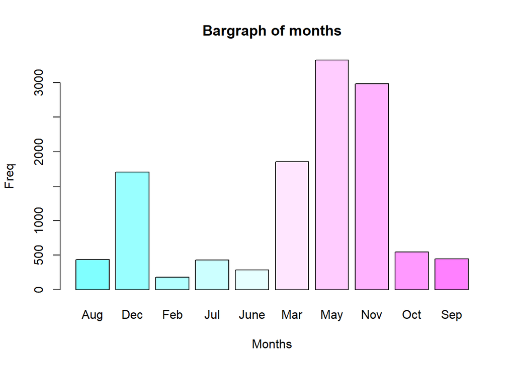

```r
#
barplot(table(ons$Month),
main = "Bargraph of months",
xlab = "Months",
ylab = "Freq",
col = cm.colors(10),
horiz = FALSE)
```

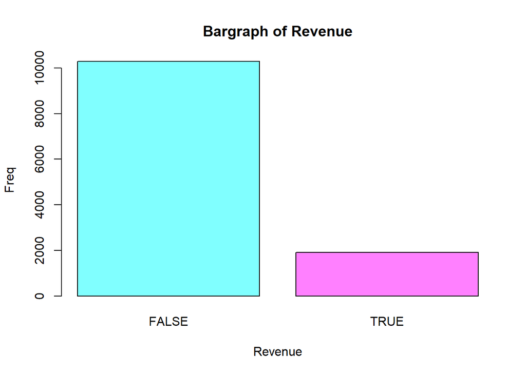

```r
#
barplot(table(ons$Revenue),
main = "Bargraph of Revenue",
xlab = "Revenue",
ylab = "Freq",
col = cm.colors(2),
horiz = FALSE)
```

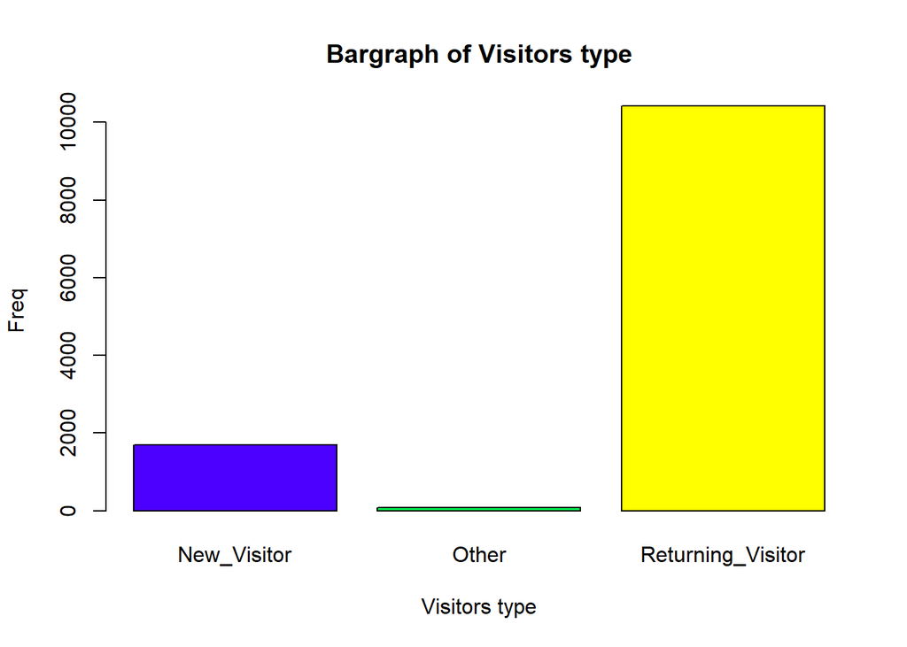

```r
#
barplot(table(ons$VisitorType),
main = "Bargraph of Visitors type",
xlab = "Visitors type",
ylab = "Freq",
col = topo.colors(3),
horiz = FALSE)
```

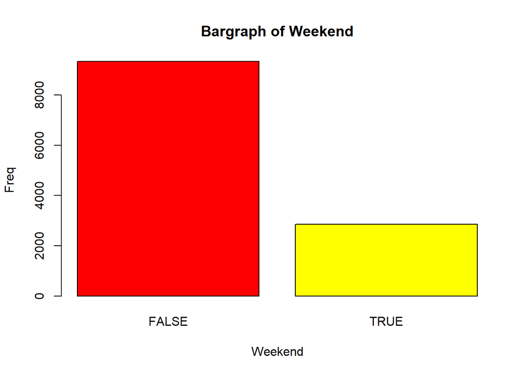

```r
#
barplot(table(ons$Weekend),
main = "Bargraph of Weekend",
xlab = "Weekend",
ylab = "Freq",
col = heat.colors(2),
horiz = FALSE)
```

### Histograms

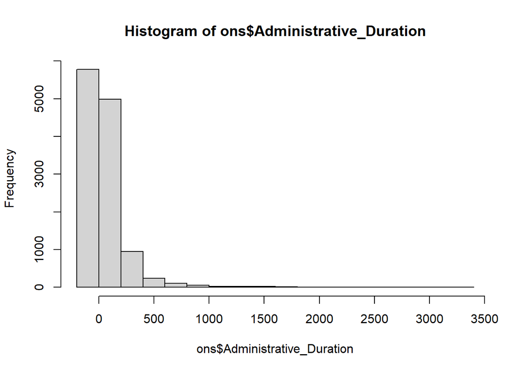

```r
hist(ons$Administrative_Duration)
```

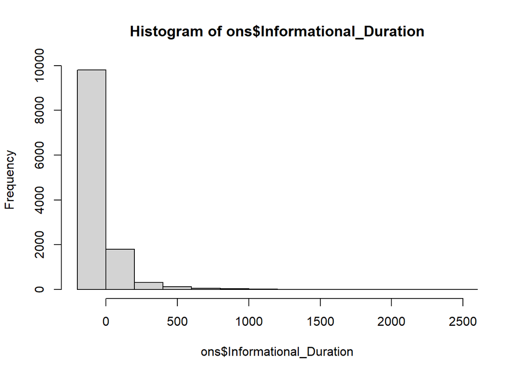

```r
hist(ons$Informational_Duration)
```

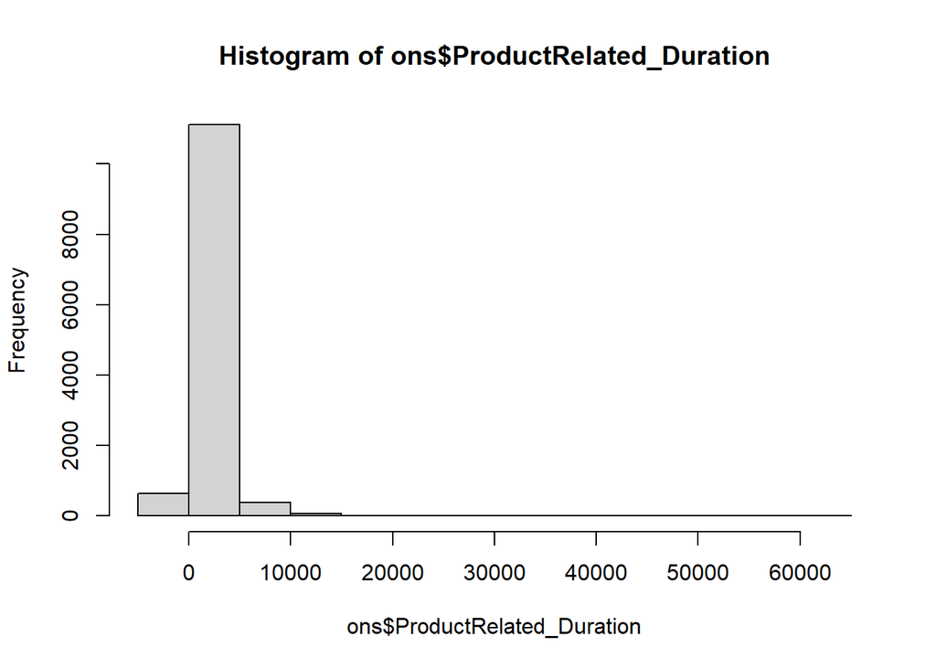

```r
hist(ons$ProductRelated_Duration)
```

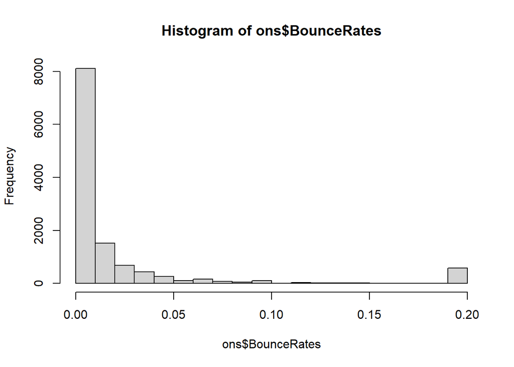

```r
hist(ons$BounceRates)
```

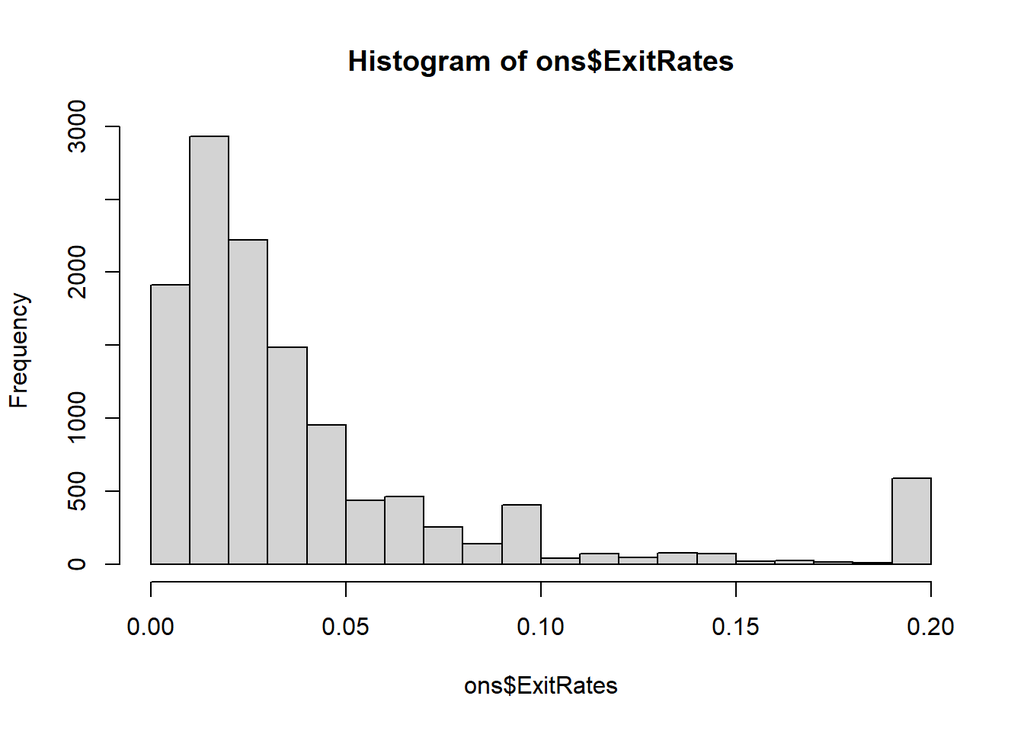

```r
hist(ons$ExitRates)
```

### Observations

- Most people visited the pages but did not bring any revenue to the brand.
- Most people visited the pages on Weekdays than the Weekends.
- Most people were returning visitors to the web pages.
- The months with the most visits were May, November, March and December.
- Most people spent 0 - 500 minutes in the Administrative pages.
- Most people spent 0 - 500 minutes in the Informational pages.
- Most people spent 0 - 10000 minutes in the Product Related pages.
- Most people had a bounce rate of 0.00 - 0.05.
- Most people had a exit rate of 0.00 - 0.10.

## Bivariate Analysis

### Plots

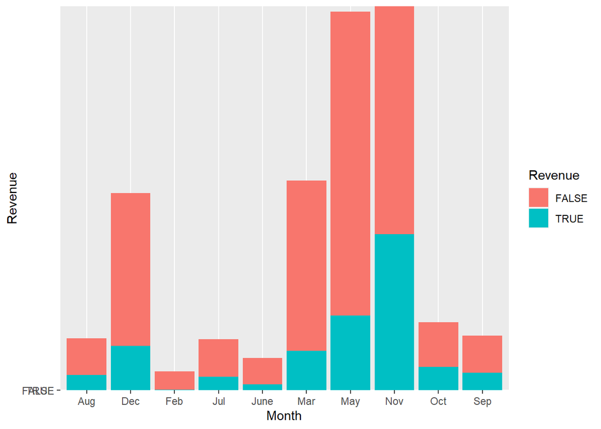

```r
library(ggplot2)
ggplot(data=ons, aes(x=Month, y=Revenue, fill=Revenue)) +
geom_bar(stat="identity")
```

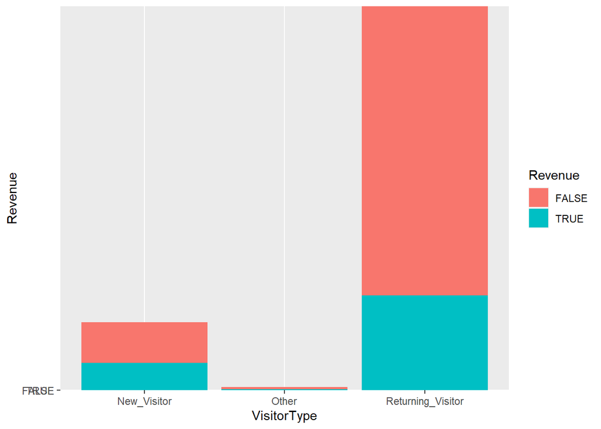

```r
ggplot(data=ons, aes(x=VisitorType, y=Revenue, fill=Revenue)) +
geom_bar(stat="identity")
```

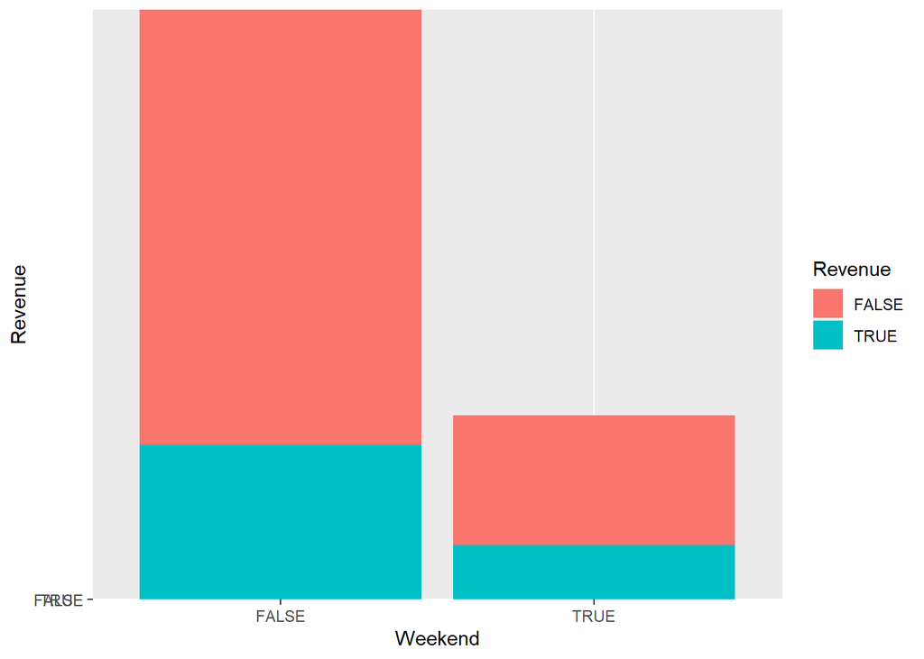

```r
ggplot(data=ons, aes(x=Weekend, y=Revenue, fill=Revenue)) +
geom_bar(stat="identity")
```

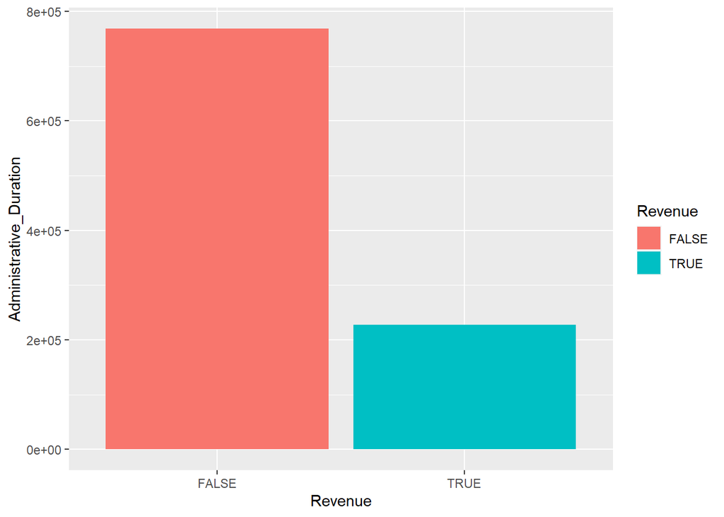

```r
ggplot(data=ons, aes(x=Revenue, y=Administrative_Duration, fill=Revenue)) +
  geom_bar(stat="identity")
```

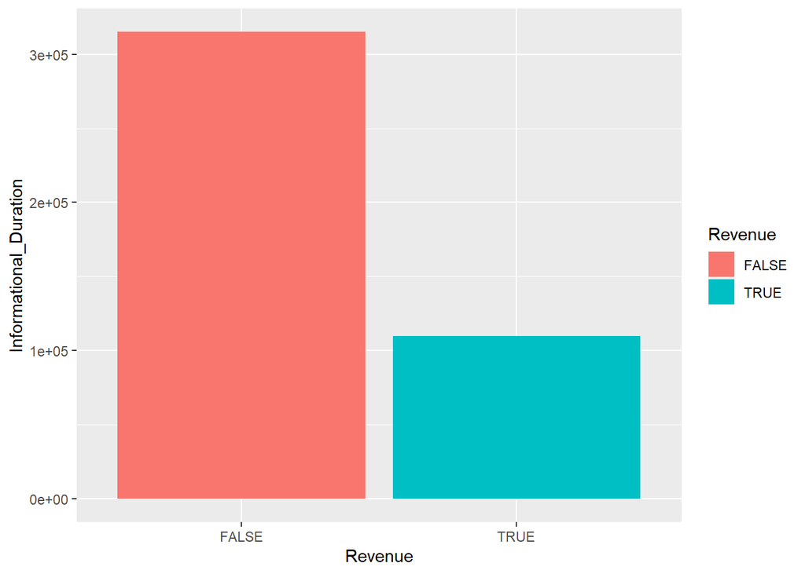

```r
ggplot(data=ons, aes(x=Revenue, y=Informational_Duration, fill=Revenue)) +
  geom_bar(stat="identity")
```

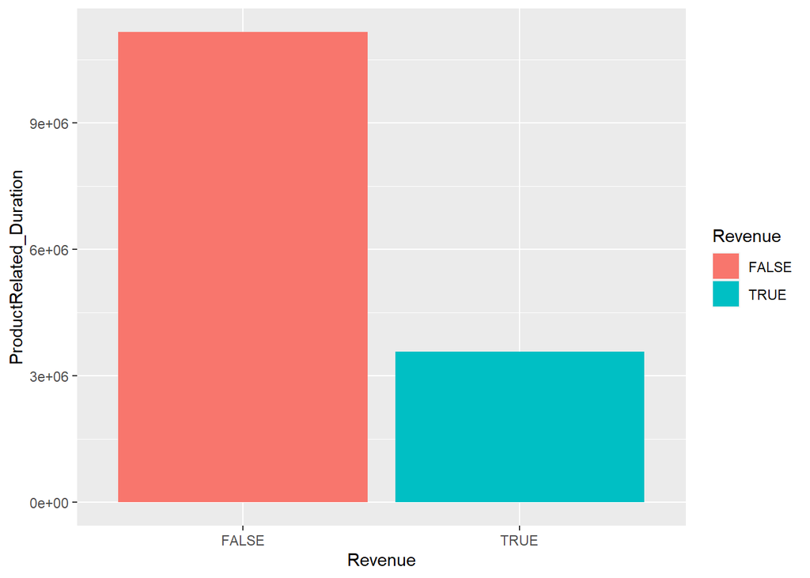

```r
ggplot(data=ons, aes(x=Revenue, y=ProductRelated_Duration, fill=Revenue)) +
  geom_bar(stat="identity")
```

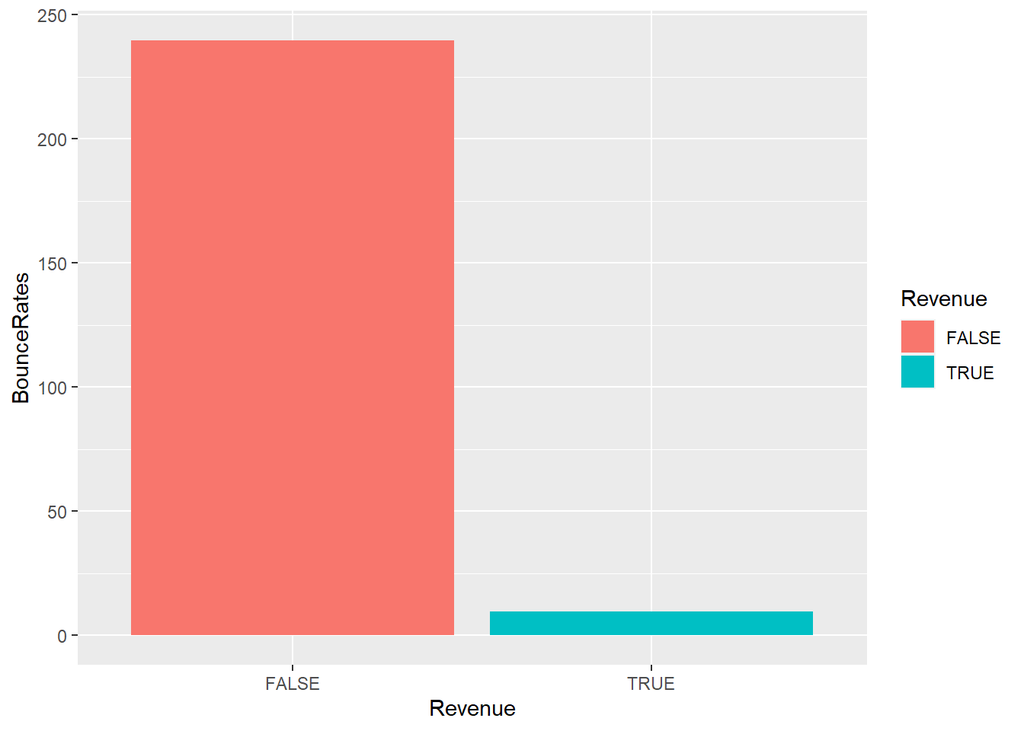

```r
ggplot(data=ons, aes(x=Revenue, y=BounceRates, fill=Revenue)) +
  geom_bar(stat="identity")
```

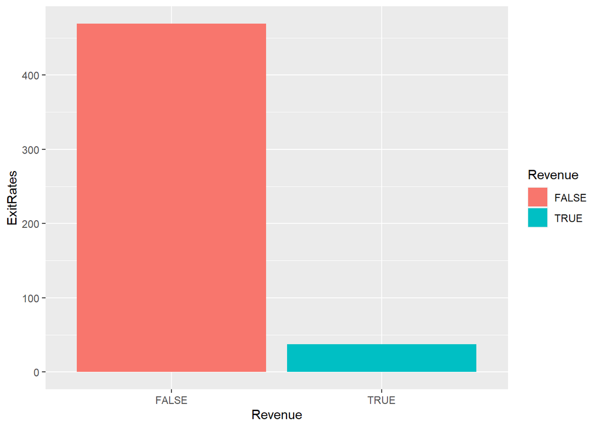

```r
ggplot(data=ons, aes(x=Revenue, y=ExitRates, fill=Revenue)) +
  geom_bar(stat="identity")
```

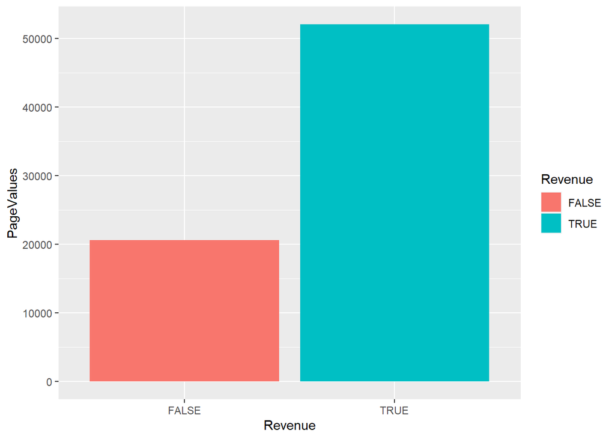

```r
ggplot(data=ons, aes(x=Revenue, y=PageValues, fill=Revenue)) +
  geom_bar(stat="identity")
```

```r
# Converting character and logical columns to integers
ons$VisitorType <- as.integer(as.factor(ons$VisitorType))
ons$Month <- as.integer(as.factor(ons$Month))
ons$Weekend <- as.integer(as.factor(ons$Weekend))
```

```r
# Checking if the columns have been converted
str(ons)
```

```
## 'data.frame':    12199 obs. of  18 variables:
##  $ Administrative         : int  0 0 0 0 0 0 0 1 0 0 ...
##  $ Administrative_Duration: num  0 0 -1 0 0 0 -1 -1 0 0 ...
##  $ Informational          : int  0 0 0 0 0 0 0 0 0 0 ...
##  $ Informational_Duration : num  0 0 -1 0 0 0 -1 -1 0 0 ...
##  $ ProductRelated         : int  1 2 1 2 10 19 1 1 2 3 ...
##  $ ProductRelated_Duration: num  0 64 -1 2.67 627.5 ...
##  $ BounceRates            : num  0.2 0 0.2 0.05 0.02 ...
##  $ ExitRates              : num  0.2 0.1 0.2 0.14 0.05 ...
##  $ PageValues             : num  0 0 0 0 0 0 0 0 0 0 ...
##  $ SpecialDay             : num  0 0 0 0 0 0 0.4 0 0.8 0.4 ...
##  $ Month                  : int  3 3 3 3 3 3 3 3 3 3 ...
##  $ OperatingSystems       : int  1 2 4 3 3 2 2 1 2 2 ...
##  $ Browser                : int  1 2 1 2 3 2 4 2 2 4 ...
##  $ Region                 : int  1 1 9 2 1 1 3 1 2 1 ...
##  $ TrafficType            : int  1 2 3 4 4 3 3 5 3 2 ...
##  $ VisitorType            : int  3 3 3 3 3 3 3 3 3 3 ...
##  $ Weekend                : int  1 1 1 1 2 1 1 2 1 1 ...
##  $ Revenue                : logi  FALSE FALSE FALSE FALSE FALSE FALSE ...
##  - attr(*, "na.action")= 'omit' Named int [1:12] 1050 1116 1117 1118 1119 1443 1444 1445 1446 1996 ...
##   ..- attr(*, "names")= chr [1:12] "1066" "1133" "1134" "1135" ...
```

```r
# Creating a Dataframe without the label variable
ons1 = ons[,-c(18)]

head(ons1)
```

```
##   Administrative Administrative_Duration Informational Informational_Duration
## 1              0                       0             0                      0
## 2              0                       0             0                      0
## 3              0                      -1             0                     -1
## 4              0                       0             0                      0
## 5              0                       0             0                      0
## 6              0                       0             0                      0
##   ProductRelated ProductRelated_Duration BounceRates ExitRates PageValues
## 1              1                0.000000  0.20000000 0.2000000          0
## 2              2               64.000000  0.00000000 0.1000000          0
## 3              1               -1.000000  0.20000000 0.2000000          0
## 4              2                2.666667  0.05000000 0.1400000          0
## 5             10              627.500000  0.02000000 0.0500000          0
## 6             19              154.216667  0.01578947 0.0245614          0
##   SpecialDay Month OperatingSystems Browser Region TrafficType VisitorType
## 1          0     3                1       1      1           1           3
## 2          0     3                2       2      1           2           3
## 3          0     3                4       1      9           3           3
## 4          0     3                3       2      2           4           3
## 5          0     3                3       3      1           4           3
## 6          0     3                2       2      1           3           3
##   Weekend
## 1       1
## 2       1
## 3       1
## 4       1
## 5       2
## 6       1
```

### Covariance

```r
# Finding the covariance of the feature variables
cov(ons1)
```

```
##                         Administrative Administrative_Duration Informational
## Administrative             11.09456996              355.034186   1.594806280
## Administrative_Duration   355.03418646            31516.250360  68.273361883
## Informational               1.59480628               68.273362   1.627709681
## Informational_Duration    120.04936778             5956.517671 111.656022657
## ProductRelated             63.61170357             2270.731540  21.202182071
## ProductRelated_Duration  2372.71642208           120492.067559 945.703033133
## BounceRates                -0.03231259               -1.106938  -0.006343127
## ExitRates                  -0.04794942               -1.658656  -0.009414909
## PageValues                  6.02328225              219.168388   1.128072018
## SpecialDay                 -0.06457297               -2.649741  -0.012580917
## Month                       0.37713419               11.984353   0.058078686
## OperatingSystems           -0.02023465               -1.225443  -0.011138556
## Browser                    -0.14679306               -4.808302  -0.084604074
## Region                     -0.05811216               -2.867667  -0.093415216
## TrafficType                -0.46527507              -10.747278  -0.180277021
## VisitorType                -0.05395338               -2.749030   0.050750278
## Weekend                     0.03393019                1.008724   0.018513885
##                         Informational_Duration ProductRelated
## Administrative                     120.0493678     63.6117036
## Administrative_Duration           5956.5176708   2270.7315396
## Informational                      111.6560227     21.2021821
## Informational_Duration           20010.5068642   1760.6514935
## ProductRelated                    1760.6514935   1989.2412959
## ProductRelated_Duration          94127.8699847  73668.6330189
## BounceRates                         -0.4506041     -0.3918681
## ExitRates                           -0.6733911     -0.5902590
## PageValues                          79.3484334     45.0324519
## SpecialDay                          -0.8840522     -0.2309712
## Month                                1.8835801      7.3668832
## OperatingSystems                    -1.2509309      0.1654644
## Browser                             -4.7449864     -1.0456925
## Region                              -9.4885165     -4.2974501
## TrafficType                        -14.2946907     -7.9424649
## VisitorType                          4.4770636      4.0107097
## Weekend                              1.3929522      0.2592289
##                         ProductRelated_Duration   BounceRates     ExitRates
## Administrative                     2.372716e+03 -3.231259e-02 -4.794942e-02
## Administrative_Duration            1.204921e+05 -1.106938e+00 -1.658656e+00
## Informational                      9.457030e+02 -6.343127e-03 -9.414909e-03
```

[output cut: 53 more lines]

```
## Informational           -1.802770e-01   0.050750278  0.0185138845
## Informational_Duration  -1.429469e+01   4.477063607  1.3929521648
## ProductRelated          -7.942465e+00   4.010709722  0.2592289053
## ProductRelated_Duration -2.891811e+02 162.473011334  4.1526243018
## BounceRates              1.626348e-02   0.004179960 -0.0007000775
## ExitRates                1.622937e-02   0.005707420 -0.0010662082
## PageValues               9.168675e-01  -1.426886143  0.0861542659
## SpecialDay               4.236803e-02   0.012006717 -0.0014914632
## Month                    4.271317e-01   0.042903199  0.0302748925
## OperatingSystems         6.660795e-01   0.002798565  0.0007250103
## Browser                  7.067625e-01  -0.022652432 -0.0286817166
## Region                   4.102726e-01  -0.057430663 -0.0017051828
## TrafficType              1.612675e+01  -0.001670331 -0.0041848640
## VisitorType             -1.670331e-03   0.481035091 -0.0125688188
## Weekend                 -4.184864e-03  -0.012568819  0.1793212228
```

### Correlation

```r
# Finding the correlation coefficients of feature variables
cor(ons1)
```

```
##                         Administrative Administrative_Duration Informational
## Administrative             1.000000000             0.600409653    0.37528761
## Administrative_Duration    0.600409653             1.000000000    0.30143630
## Informational              0.375287611             0.301436296    1.00000000
## Informational_Duration     0.254786021             0.237189860    0.61867795
## ProductRelated             0.428191515             0.286783914    0.37260472
## ProductRelated_Duration    0.371027224             0.353513793    0.38608372
## BounceRates               -0.213666635            -0.137333397   -0.10950530
## ExitRates                 -0.311274132            -0.202024452   -0.15956681
## PageValues                 0.096920968             0.066168365    0.04739015
## SpecialDay                -0.097072098            -0.074736885   -0.04937677
## Month                      0.047676102             0.028425453    0.01916851
## OperatingSystems          -0.006697922            -0.007610715   -0.00962587
## Browser                   -0.025763658            -0.015833675   -0.03876681
## Region                    -0.007262053            -0.006723711   -0.03047732
## TrafficType               -0.034784126            -0.015075015   -0.03518669
## VisitorType               -0.023354742            -0.022326663    0.05735372
## Weekend                    0.024055542             0.013418049    0.03426835
##                         Informational_Duration ProductRelated
## Administrative                     0.254786021    0.428191515
## Administrative_Duration            0.237189860    0.286783914
## Informational                      0.618677947    0.372604721
## Informational_Duration             1.000000000    0.279061948
## ProductRelated                     0.279061948    1.000000000
## ProductRelated_Duration            0.346580691    0.860308186
## BounceRates                       -0.070159472   -0.193515772
## ExitRates                         -0.102932678   -0.286163211
## PageValues                         0.030064160    0.054115494
## SpecialDay                        -0.031293040   -0.025930622
## Month                              0.005606801    0.069550478
## OperatingSystems                  -0.009749983    0.004090351
## Browser                           -0.019609349   -0.013706213
## Region                            -0.027920098   -0.040106501
## TrafficType                       -0.025163571   -0.044344333
## VisitorType                        0.045632666    0.129654955
## Weekend                            0.023253660    0.013725363
##                         ProductRelated_Duration  BounceRates    ExitRates
## Administrative                      0.371027224 -0.213666635 -0.311274132
## Administrative_Duration             0.353513793 -0.137333397 -0.202024452
## Informational                       0.386083717 -0.109505298 -0.159566815
```

[output cut: 53 more lines]

```
## Informational            0.034268353
## Informational_Duration   0.023253660
## ProductRelated           0.013725363
## ProductRelated_Duration  0.005107660
## BounceRates             -0.036412499
## ExitRates               -0.054442881
## PageValues               0.010904373
## SpecialDay              -0.017635818
## Month                    0.030104182
## OperatingSystems         0.001887678
## Browser                 -0.039595564
## Region                  -0.001676111
## TrafficType             -0.002460889
## VisitorType             -0.042794725
## Weekend                  1.000000000
```

### Correlation Matrix

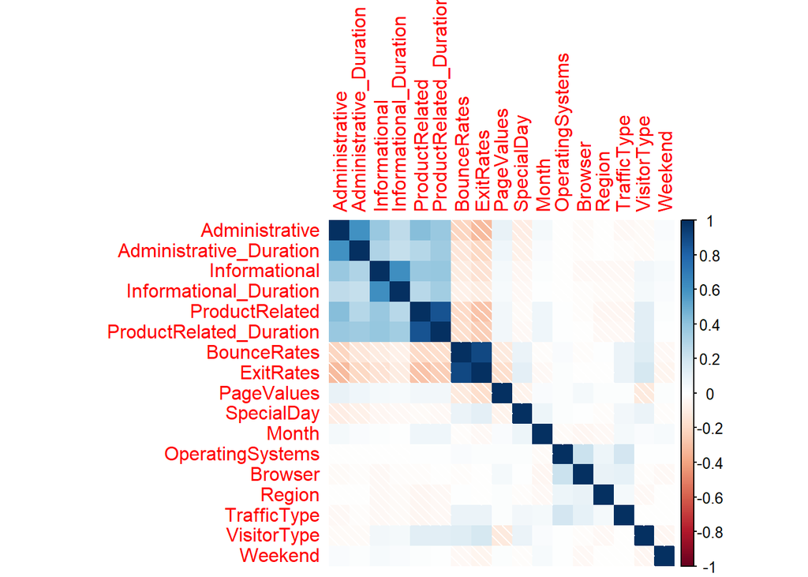

```r
# Creating a correlation matrix
library('corrplot')
corrplot(cor(ons1), method = "shade")
```

From the correlation and correlation matrix output it shows Bounce rates and Exit rates have a high correlation between them. Most features have correlation close to zero.

### Scatter Plots

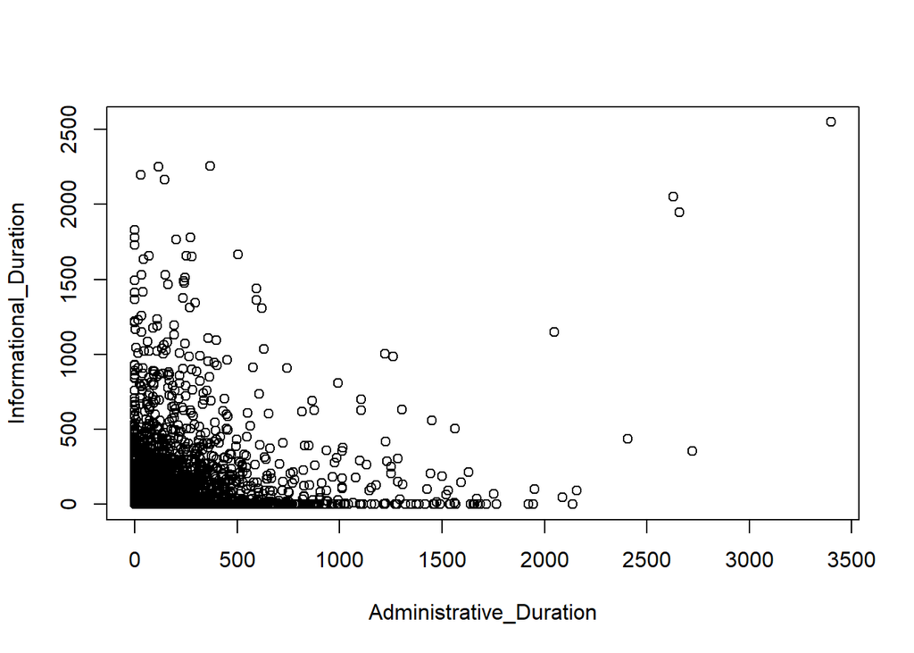

```r
# Plotting a scatterplot between Administrative_Duration and Informational_Duration
plot(ons$Administrative_Duration, ons$Informational_Duration, xlab="Administrative_Duration", ylab="Informational_Duration")
```

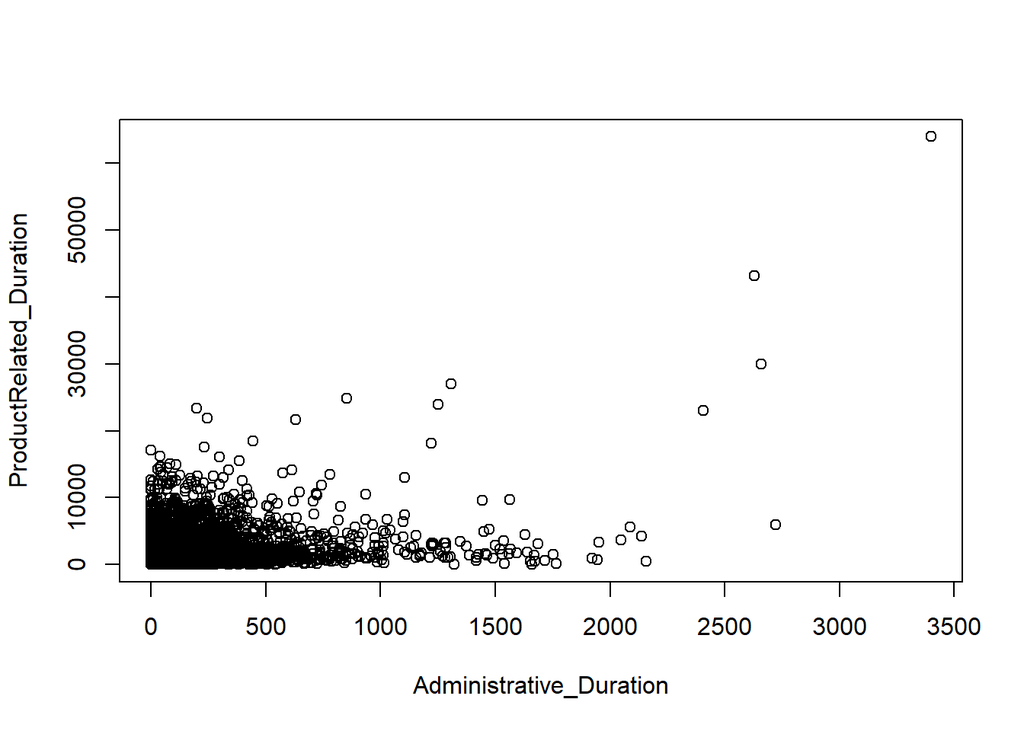

```r
# Plotting a scatterplot between Administrative_Duration and ProductRelated_Duration
plot(ons$Administrative_Duration, ons$ProductRelated_Duration, xlab="Administrative_Duration", ylab="ProductRelated_Duration")
```

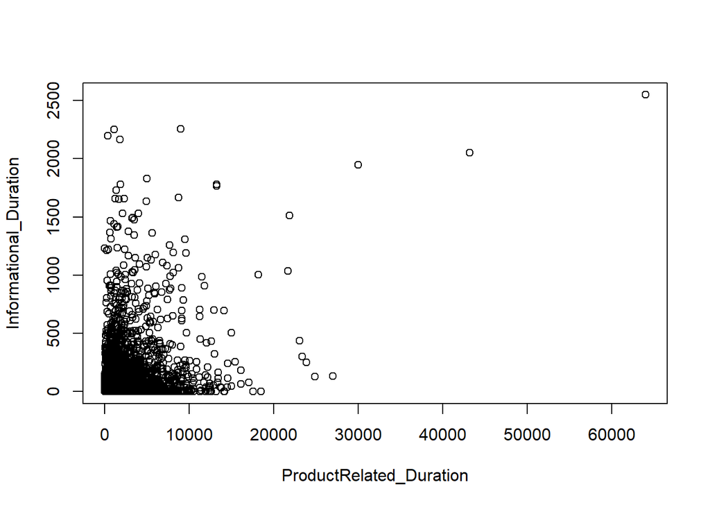

```r
# Plotting a scatterplot between ProductRelated_Duration and Informational_Duration
plot(ons$ProductRelated_Duration, ons$Informational_Duration, xlab="ProductRelated_Duration", ylab="Informational_Duration")
```

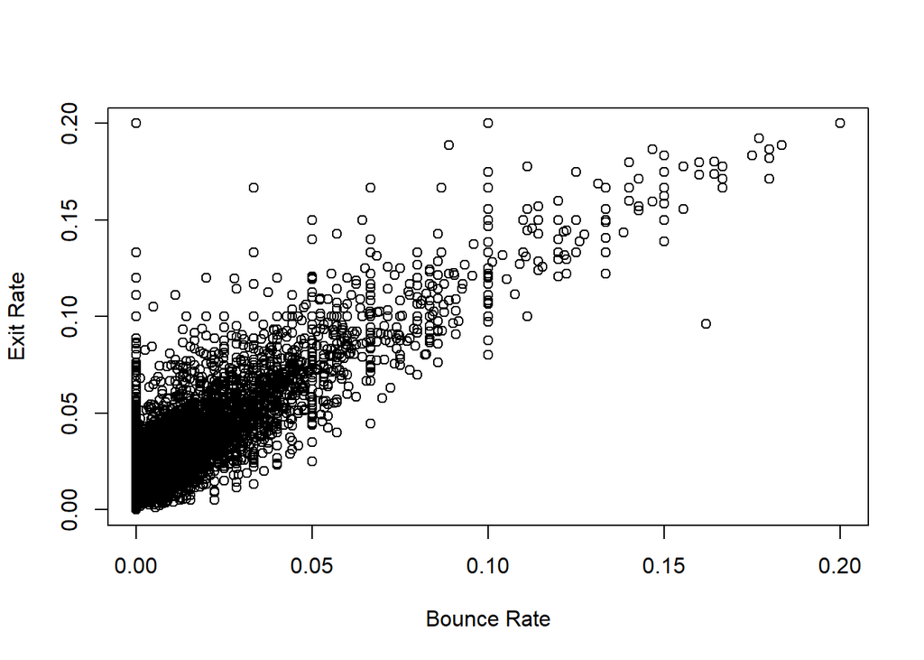

```r
# Plotting a scatterplot between Bounce Rate and Exit Rate
plot(ons$BounceRates, ons$ExitRates, xlab="Bounce Rate", ylab="Exit Rate")
```

### Observations

- The month of November had the most people who returned revenue to the brand while the month of May had the most people who did not return revenue to the brand.
- The returning visitors returned more revenue compared to new visitors and others.
- Most of the revenue was returned on weekdays compared to weekends.
- Customers who spent more time in the Administrative page did not return revenue.
- Customers who spent more time in the Informational page did not return revenue.
- Customers who spent more time in the Product related page did not return revenue.
- Most customers who bounced off the pages in the did not return revenue.
- Most customers who exited the pages in the did not return revenue.
- Most customers who returned revenue had the most page values.
- Bounce rate and Exit rates had a very high positive correlation of 0.9.